# Assignment 1, Wind Power Forecase, DTU02418

# Regression Model

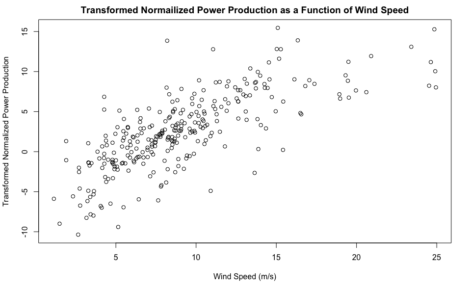

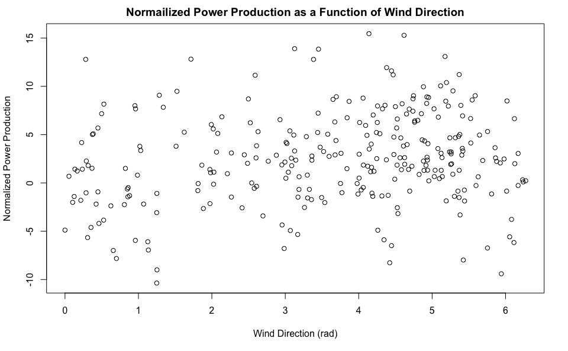

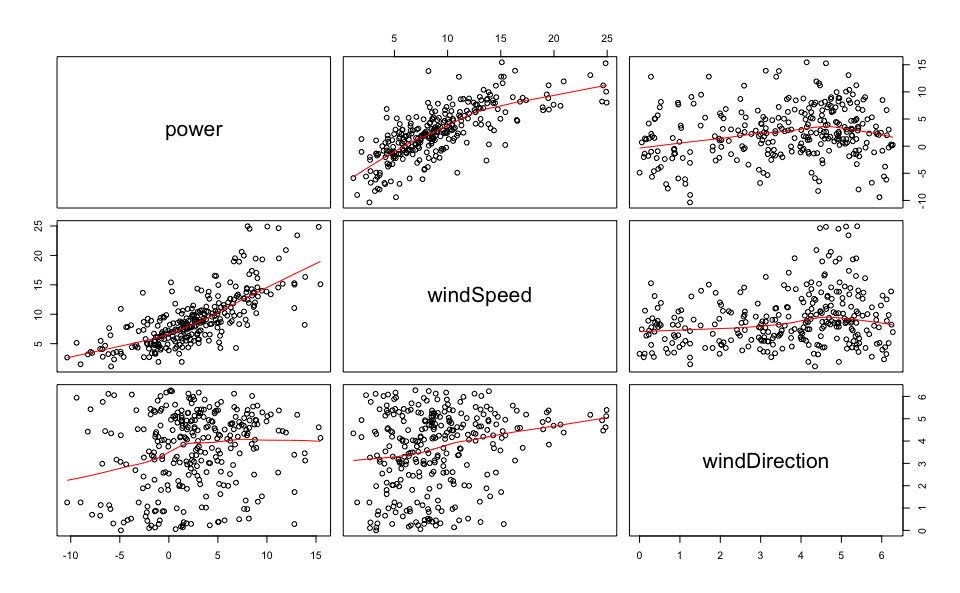

```r
# Scatterplot Matrices
pairs(cbind(y.trans, x1, x2), labels = c('power', 'windSpeed', 'windDirection'), panel = panel.smooth)
```

The response variables are named in the rows and the explanatory variables are named in the columns.

## Regression Model 1: Multiple, y.trans ~ x1, x1^2, x1^3, x2

Result of the regression analysis 1.

|  | Estimate | Std. Error | t value | Pr(>\|t\|) |
| --- | --- | --- | --- | --- |
| (Intercept) | -7.5562453 | 1.3392233 | -5.6422592 | 0.0000000 |
| x1 | 1.4281383 | 0.3944942 | 3.6201756 | 0.0003487 |
| I(x1^2) | -0.0293810 | 0.0352472 | -0.8335693 | 0.4052267 |
| I(x1^3) | 0.0000464 | 0.0009144 | 0.0507881 | 0.9595302 |
| x2 | 0.0166491 | 0.1071807 | 0.1553372 | 0.8766662 |

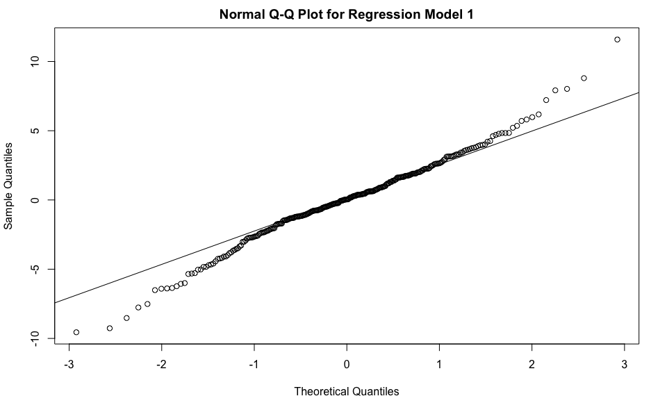

```r
qqnorm(regression_1$residuals, main = "Normal Q-Q Plot for Regression Model 1")
qqline(regression_1$residuals)
```

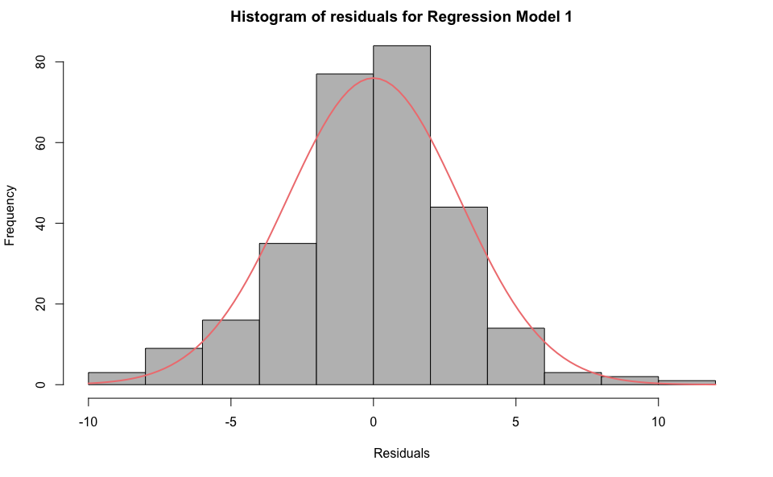

```r
residuals_regression_1 <- regression_1$residuals # sample
hist_residuals_regression_1 <- hist(residuals_regression_1, plot = FALSE) # generate hist
plot(hist_residuals_regression_1, col = "grey", main = 'Histogram of residuals for Regression Model 1', xlab = 'Residuals') # plot hist
xlines <- seq(min(hist_residuals_regression_1$breaks), max(hist_residuals_regression_1$breaks), length.out = 100) # seq of x for pdf
lines(xlines, dnorm(xlines, mean(residuals_regression_1), sd(residuals_regression_1)) *  length(residuals_regression_1) * diff(hist_residuals_regression_1$breaks)[1], col = "lightcoral", lwd = 2)
```

A histogram of the residuals is shown in the above figure, where it seems that they are quite well-behaved and approximately follows a normal distribution.

## Regression Model 3: Multiple, y.trans ~ x1^2, x1^3, x2

```r
# Initialize regression model 3 using glm
regression_3 <- glm(y.trans ~ I(x1^2) + I(x1^3) + x2)  # I() is the identity function that returns its argument unaltered.
# Plot the rediction result of regression model 3
predictRegression.windSpeed(x1.pred, x2, y.trans, regression_3)
```

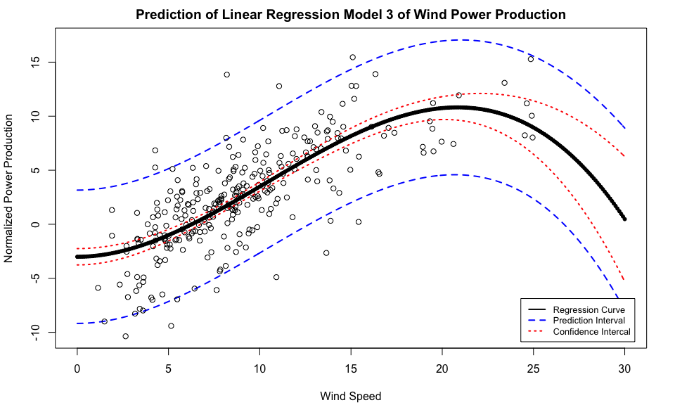

```r
title(main = 'Prediction of Linear Regression Model 3 of Wind Power Production')
```

Result of the regression analysis 3.

|  | Estimate | Std. Error | t value | Pr(>\|t\|) |
| --- | --- | --- | --- | --- |
| (Intercept) | -3.0502607 | 0.5046647 | -6.0441334 | 0.0000000 |
| I(x1^2) | 0.0954312 | 0.0074835 | 12.7522030 | 0.0000000 |
| I(x1^3) | -0.0030520 | 0.0003286 | -9.2870823 | 0.0000000 |
| x2 | 0.0119431 | 0.1094331 | 0.1091361 | 0.9131716 |

## Regression Model 4: Multiple, y.trans ~ x1^3, x2

```r
# Initialize regression model 4
regression_4 <- glm(y.trans ~ I(x1^3) + x2)  # I() is the identity function that returns its argument unaltered.
# Plot the rediction result of regression model 4
predictRegression.windSpeed(x1.pred, x2, y.trans, regression_4)
```

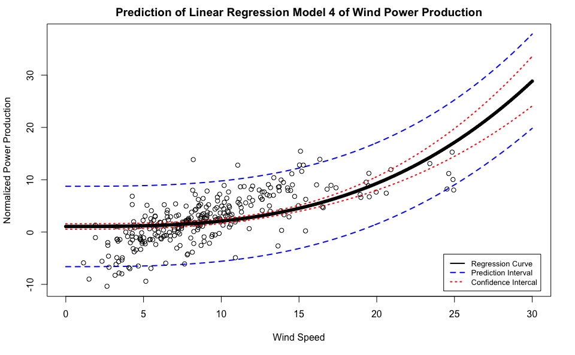

```r
title(main = 'Prediction of Linear Regression Model 4 of Wind Power Production')
```

Result of the regression analysis 4.

|  | Estimate | Std. Error | t value | Pr(>\|t\|) |
| --- | --- | --- | --- | --- |
| (Intercept) | 0.4286595 | 0.5314930 | 0.8065197 | 0.4206158 |
| I(x1^3) | 0.0010285 | 0.0000937 | 10.9737963 | 0.0000000 |
| x2 | 0.1771172 | 0.1360289 | 1.3020556 | 0.1939487 |

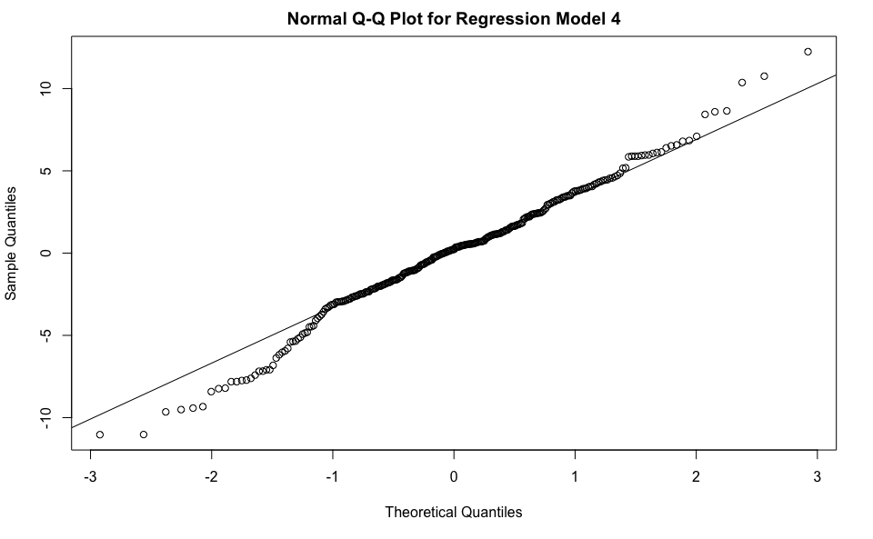

```r
qqnorm(regression_4$residuals, main = "Normal Q-Q Plot for Regression Model 4")
qqline(regression_4$residuals)
```

## Regression Model 2: Polynomial, y.trans ~ x1, x1^2, x1^3

```r
# Initialize regression model 2
regression_2 <- glm(y.trans ~ x1 + I(x1^2) + I(x1^3))
# Plot the rediction result of regression model 2
predictRegression.windSpeed(x1.pred, x2, y.trans, regression_2)
```

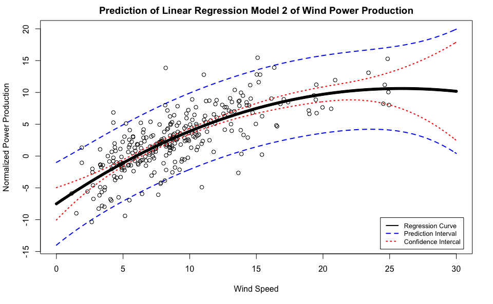

```r
title(main = 'Prediction of Linear Regression Model 2 of Wind Power Production')
```

Result of the regression analysis 2.

|  | Estimate | Std. Error | t value | Pr(>\|t\|) |
| --- | --- | --- | --- | --- |
| (Intercept) | -7.5031520 | 1.2926466 | -5.8044885 | 0.0000000 |
| x1 | 1.4273950 | 0.3937869 | 3.6247908 | 0.0003426 |
| I(x1^2) | -0.0291813 | 0.0351632 | -0.8298820 | 0.4073025 |
| I(x1^3) | 0.0000415 | 0.0009123 | 0.0454862 | 0.9637517 |

## Regression Model 5: Polynomial, y.trans ~ x1^2, x1^3

```r
# Initialize regression model 5
regression_5 <- glm(y.trans ~ I(x1^2) + I(x1^3))
# Plot the rediction result of regression model 5
predictRegression.windSpeed(x1.pred, x2, y.trans, regression_5)
```

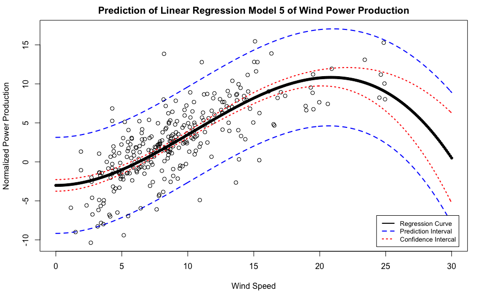

```r
title(main = 'Prediction of Linear Regression Model 5 of Wind Power Production')
```

Result of the regression analysis 5.

|  | Estimate | Std. Error | t value | Pr(>\|t\|) |
| --- | --- | --- | --- | --- |
| (Intercept) | -3.0138516 | 0.3780113 | -7.972913 | 0 |
| I(x1^2) | 0.0955279 | 0.0074180 | 12.877829 | 0 |
| I(x1^3) | -0.0030544 | 0.0003273 | -9.331264 | 0 |

## Regression Model 6: Simple, y.trans ~ x1^3

```r
# Initialize regression model 6
regression_6 <- glm(y.trans ~ I(x1^3))
# Plot the rediction result of regression model 6
predictRegression.windSpeed(x1.pred, x2, y.trans, regression_6)
```

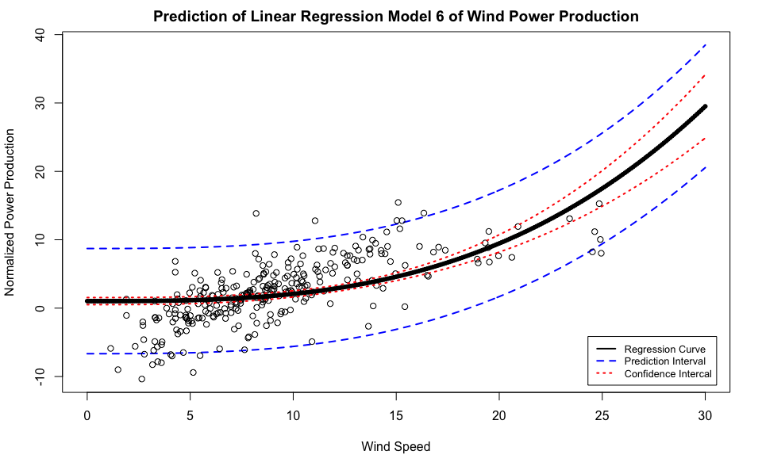

```r
title(main = 'Prediction of Linear Regression Model 6 of Wind Power Production')
```

Result of the regression analysis 6.

|  | Estimate | Std. Error | t value | Pr(>\|t\|) |
| --- | --- | --- | --- | --- |
| (Intercept) | 1.0292846 | 0.2643215 | 3.894063 | 0.0001228 |
| I(x1^3) | 0.0010547 | 0.0000916 | 11.508407 | 0.0000000 |

## Regression 7: Multiple Regression, y ~ x1^3, x2

```r
# Initialize regression model 1
regression_7 <- glm(y ~ I(x1^3) + x2)  # I() is the identity function that returns its argument unaltered.
# Plot the rediction result of regression model 1
predictRegression.windSpeed(x1.pred, x2, y, regression_7)
```

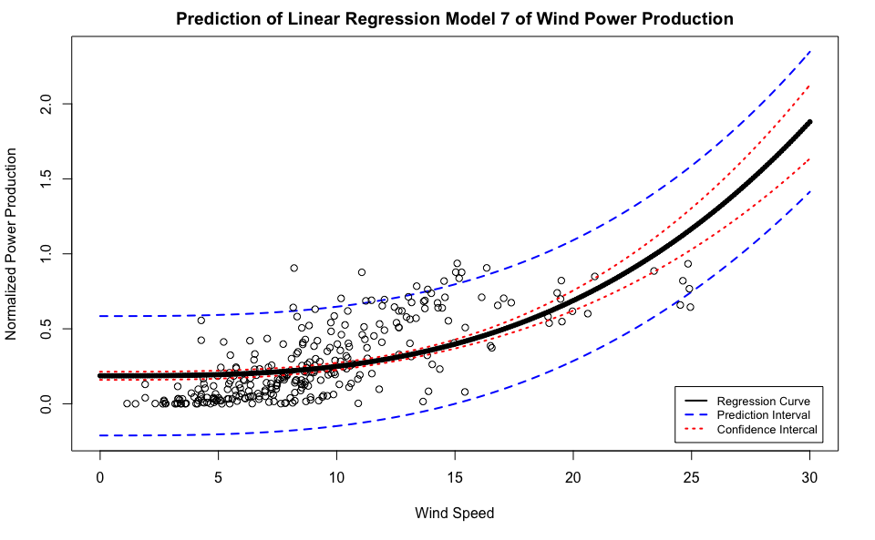

```r
title(main = 'Prediction of Linear Regression Model 7 of Wind Power Production')
```

Result of the regression analysis 7.

|  | Estimate | Std. Error | t value | Pr(>\|t\|) |
| --- | --- | --- | --- | --- |
| (Intercept) | 0.1741396 | 0.0275446 | 6.3220960 | 0.0000000 |
| I(x1^3) | 0.0000627 | 0.0000049 | 12.9142492 | 0.0000000 |
| x2 | 0.0034833 | 0.0070497 | 0.4941097 | 0.6216093 |

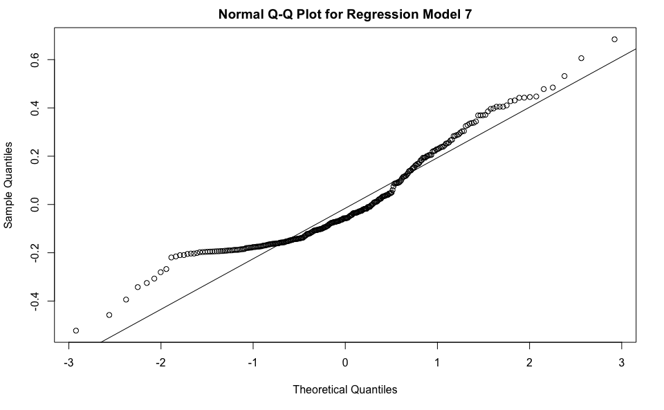

```r
qqnorm(regression_7$residuals, main = "Normal Q-Q Plot for Regression Model 7")
qqline(regression_7$residuals)
```

```r
# Initialize regression model 1
regression_8 <- glm(y ~ I(x1^2) + I(x1^3) + x2)  # I() is the identity function that returns its argument unaltered.
# Plot the rediction result of regression model 1
predictRegression.windSpeed(x1.pred, x2, y, regression_8)
```

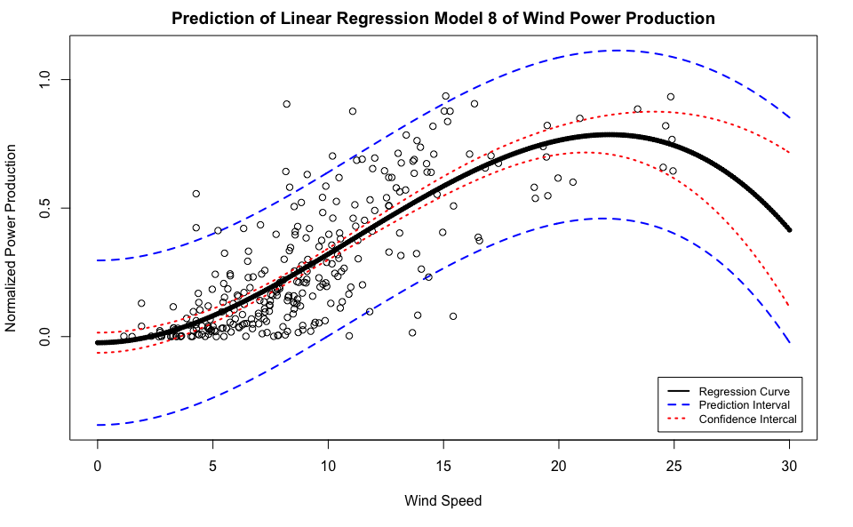

```r
title(main = 'Prediction of Linear Regression Model 8 of Wind Power Production')
```

Result of the regression analysis 8.

|  | Estimate | Std. Error | t value | Pr(>\|t\|) |
| --- | --- | --- | --- | --- |
| (Intercept) | -0.0056105 | 0.0261994 | -0.2141466 | 0.8305864 |
| I(x1^2) | 0.0049308 | 0.0003885 | 12.6917636 | 0.0000000 |
| I(x1^3) | -0.0001481 | 0.0000171 | -8.6811567 | 0.0000000 |
| x2 | -0.0050510 | 0.0056812 | -0.8890714 | 0.3747171 |

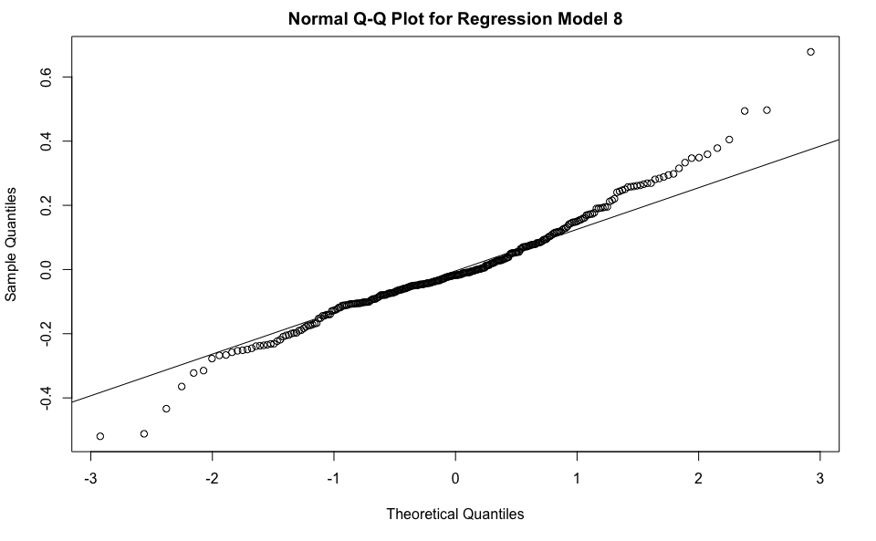

```r
qqnorm(regression_8$residuals, main = "Normal Q-Q Plot for Regression Model 8")
qqline(regression_8$residuals)
```

## Final Model

| Name | Expression | Type | AIC |
| --- | --- | --- | --- |
| regression_1 | y.trans ~ x1, x1^2, x1^3, x2 | Transformed Multiple Regression | 1465.73568 |
| regression_2 | y.trans ~ x1, x1^2, x1^3 | Transformed Polynomial Regression | 1463.76023 |
| regression_3 | y.trans ~ x1^2, x1^3, x2 | Transformed Multiple Regression | 1476.77329 |
| regression_4 | y.trans ~ x1^3, x2 | Transformed Multiple Regression | 1605.15980 |
| regression_5 | y.trans ~ x1^2, x1^3 | Transformed Polynomial Regression | 1474.78537 |
| regression_6 | y.trans ~ x1^3 | Transformed Simple Regression | 1604.86792 |
| regression_7 | y ~ x1^3, x2 | Multiple Regression | -99.73305 |
| regression_8 | y ~ x1^2, x1^3, x2 | Multiple Regression | -227.12619 |